# R Notebook

Cleaning Data in R

Types of variables in R As in other programming languages, R is capable of storing data in many different formats, most of which you’ve probably seen by now.

Loosely speaking, the class() function tells you what type of object you’re working with. (There are subtle differences between the class, type, and mode of an object, but these distinctions are beyond the scope of this course.)

```r
# Make this evaluate to character
class("true")
```

```
[1] "character"
```

```r
# Make this evaluate to numeric
class(8484.00)
```

```
[1] "numeric"
```

```r
# Make this evaluate to integer
class(99L)
```

```
[1] "integer"
```

```r
# Make this evaluate to factor
class(factor("factor"))
```

```
[1] "factor"
```

```r
# Make this evaluate to logical
class(FALSE)
```

```
[1] "logical"
```

Common type conversions It is often necessary to change, or coerce, the way that variables in a dataset are stored. This could be because of the way they were read into R (with read.csv(), for example) or perhaps the function you are using to analyze the data requires variables to be coded a certain way.

There are a few less intuitive results. For example, under the hood, the logical values TRUE and FALSE are coded as 1 and 0, respectively. Therefore, as.logical(1) returns TRUE and as.numeric(TRUE) returns 1.

```r
students = read.csv("students_with_dates.csv")
head(students)
```

|  | X | school | sex | dob | address | famsize | Pstatus | Medu | Fedu | Mjob | Fjob | reason | guardian | traveltime | studytime | failures | schoolsup | famsup | paid | activities | nursery | higher | internet | romantic | famrel | freetime | goout | Dalc | Walc | … |
| --- | --- | --- | --- | --- | --- | --- | --- | --- | --- | --- | --- | --- | --- | --- | --- | --- | --- | --- | --- | --- | --- | --- | --- | --- | --- | --- | --- | --- | --- | --- |
| 1 | 1 | GP | F | 2000-06-05 | U | GT3 | A | 4 | 4 | at_home | teacher | course | mother | 2 | 2 | 0 | yes | no | no | no | yes | yes | no | no | 4 | 3 | 4 | 1 | 1 | … |
| 2 | 2 | GP | F | 1999-11-25 | U | GT3 | T | 1 | 1 | at_home | other | course | father | 1 | 2 | 0 | no | yes | no | no | no | yes | yes | no | 5 | 3 | 3 | 1 | 1 | … |
| 3 | 3 | GP | F | 1998-02-02 | U | LE3 | T | 1 | 1 | at_home | other | other | mother | 1 | 2 | 3 | yes | no | yes | no | yes | yes | yes | no | 4 | 3 | 2 | 2 | 3 | … |
| 4 | 4 | GP | F | 1997-12-20 | U | GT3 | T | 4 | 2 | health | services | home | mother | 1 | 3 | 0 | no | yes | yes | yes | yes | yes | yes | yes | 3 | 2 | 2 | 1 | 1 | … |
| 5 | 5 | GP | F | 1998-10-04 | U | GT3 | T | 3 | 3 | other | other | home | father | 1 | 2 | 0 | no | yes | yes | no | yes | yes | no | no | 4 | 3 | 2 | 1 | 2 | … |
| 6 | 6 | GP | M | 1999-06-16 | U | LE3 | T | 4 | 3 | services | other | reputation | mother | 1 | 2 | 0 | no | yes | yes | yes | yes | yes | yes | no | 5 | 4 | 2 | 1 | 2 | … |

```r
names(students)
```

```
 [1] "X"           "school"      "sex"         "dob"         "address"     "famsize"
 [7] "Pstatus"     "Medu"        "Fedu"        "Mjob"        "Fjob"        "reason"
[13] "guardian"    "traveltime"  "studytime"   "failures"    "schoolsup"   "famsup"
[19] "paid"        "activities"  "nursery"     "higher"      "internet"    "romantic"
[25] "famrel"      "freetime"    "goout"       "Dalc"        "Walc"        "health"
[31] "nurse_visit" "absences"    "Grades"
```

```r
# Preview students with str()
str(students)
```

```
'data.frame':   395 obs. of  33 variables:
 $ X          : int  1 2 3 4 5 6 7 8 9 10 ...
 $ school     : Factor w/ 2 levels "GP","MS": 1 1 1 1 1 1 1 1 1 1 ...
 $ sex        : Factor w/ 2 levels "F","M": 1 1 1 1 1 2 2 1 2 2 ...
 $ dob        : Factor w/ 345 levels "1996-11-02","1996-11-03",..: 313 267 113 100 162 224 79 147 292 44 ...
 $ address    : Factor w/ 2 levels "R","U": 2 2 2 2 2 2 2 2 2 2 ...
 $ famsize    : Factor w/ 2 levels "GT3","LE3": 1 1 2 1 1 2 2 1 2 1 ...
 $ Pstatus    : Factor w/ 2 levels "A","T": 1 2 2 2 2 2 2 1 1 2 ...
 $ Medu       : int  4 1 1 4 3 4 2 4 3 3 ...
 $ Fedu       : int  4 1 1 2 3 3 2 4 2 4 ...
 $ Mjob       : Factor w/ 5 levels "at_home","health",..: 1 1 1 2 3 4 3 3 4 3 ...
 $ Fjob       : Factor w/ 5 levels "at_home","health",..: 5 3 3 4 3 3 3 5 3 3 ...
 $ reason     : Factor w/ 4 levels "course","home",..: 1 1 3 2 2 4 2 2 2 2 ...
 $ guardian   : Factor w/ 3 levels "father","mother",..: 2 1 2 2 1 2 2 2 2 2 ...
 $ traveltime : int  2 1 1 1 1 1 1 2 1 1 ...
```

[output cut: 19 more lines]

```r
# Coerce Grades to character
students$Grades <- as.character(students$Grades)
# Coerce Medu to factor
students$Medu <- as.factor(students$Medu)
# Coerce Fedu to factor
students$Fedu <- as.factor(students$Fedu)

# Look at students once more with str()
str(students)
```

```
'data.frame':   395 obs. of  33 variables:
 $ X          : int  1 2 3 4 5 6 7 8 9 10 ...
 $ school     : Factor w/ 2 levels "GP","MS": 1 1 1 1 1 1 1 1 1 1 ...
 $ sex        : Factor w/ 2 levels "F","M": 1 1 1 1 1 2 2 1 2 2 ...
 $ dob        : Factor w/ 345 levels "1996-11-02","1996-11-03",..: 313 267 113 100 162 224 79 147 292 44 ...
 $ address    : Factor w/ 2 levels "R","U": 2 2 2 2 2 2 2 2 2 2 ...
 $ famsize    : Factor w/ 2 levels "GT3","LE3": 1 1 2 1 1 2 2 1 2 1 ...
 $ Pstatus    : Factor w/ 2 levels "A","T": 1 2 2 2 2 2 2 1 1 2 ...
 $ Medu       : Factor w/ 5 levels "0","1","2","3",..: 5 2 2 5 4 5 3 5 4 4 ...
 $ Fedu       : Factor w/ 5 levels "0","1","2","3",..: 5 2 2 3 4 4 3 5 3 5 ...
 $ Mjob       : Factor w/ 5 levels "at_home","health",..: 1 1 1 2 3 4 3 3 4 3 ...
 $ Fjob       : Factor w/ 5 levels "at_home","health",..: 5 3 3 4 3 3 3 5 3 3 ...
 $ reason     : Factor w/ 4 levels "course","home",..: 1 1 3 2 2 4 2 2 2 2 ...
 $ guardian   : Factor w/ 3 levels "father","mother",..: 2 1 2 2 1 2 2 2 2 2 ...
 $ traveltime : int  2 1 1 1 1 1 1 2 1 1 ...
```

[output cut: 19 more lines]

Working with dates Dates can be a challenge to work with in any programming language, but thanks to the lubridate package, working with dates in R isn’t so bad. Since this course is about cleaning data, we only cover the most basic functions from lubridate to help us standardize the format of dates and times in our data.

As you saw in the video, these functions combine the letters y, m, d, h, m, s, which stand for year, month, day, hour, minute, and second, respectively. The order of the letters in the function should match the order of the date/time you are attempting to read in, although not all combinations are valid. Notice that the functions are “smart” in that they are capable of parsing multiple formats.

```r
# Preview students2 with str()
str(students)
```

[output not shown]

[output cut: 19 more lines]

```r
# Load the lubridate package
library(lubridate)
# Parse as date
dmy("17 Sep 2015")
```

```
[1] "2015-09-17"
```

```r
# Parse as date and time (with no seconds!)
mdy_hm("July 15, 2012 12:56")
```

```
[1] "2012-07-15 12:56:00 UTC"
```

```r
# Coerce dob to a date (with no time)
students$dob <- ymd(students$dob)
# Coerce nurse_visit to a date and time
students$nurse_visit <- ymd_hms(students$nurse_visit)

# Look at students2 once more with str()
str(students)
```

```
'data.frame':   395 obs. of  33 variables:
 $ X          : int  1 2 3 4 5 6 7 8 9 10 ...
 $ school     : Factor w/ 2 levels "GP","MS": 1 1 1 1 1 1 1 1 1 1 ...
 $ sex        : Factor w/ 2 levels "F","M": 1 1 1 1 1 2 2 1 2 2 ...
 $ dob        : Date, format: "2000-06-05" "1999-11-25" "1998-02-02" ...
 $ address    : Factor w/ 2 levels "R","U": 2 2 2 2 2 2 2 2 2 2 ...
 $ famsize    : Factor w/ 2 levels "GT3","LE3": 1 1 2 1 1 2 2 1 2 1 ...
 $ Pstatus    : Factor w/ 2 levels "A","T": 1 2 2 2 2 2 2 1 1 2 ...
 $ Medu       : Factor w/ 5 levels "0","1","2","3",..: 5 2 2 5 4 5 3 5 4 4 ...
 $ Fedu       : Factor w/ 5 levels "0","1","2","3",..: 5 2 2 3 4 4 3 5 3 5 ...
 $ Mjob       : Factor w/ 5 levels "at_home","health",..: 1 1 1 2 3 4 3 3 4 3 ...
 $ Fjob       : Factor w/ 5 levels "at_home","health",..: 5 3 3 4 3 3 3 5 3 3 ...
 $ reason     : Factor w/ 4 levels "course","home",..: 1 1 3 2 2 4 2 2 2 2 ...
 $ guardian   : Factor w/ 3 levels "father","mother",..: 2 1 2 2 1 2 2 2 2 2 ...
 $ traveltime : int  2 1 1 1 1 1 1 2 1 1 ...
```

[output cut: 19 more lines]

Working with Strings Trimming and padding strings One common issue that comes up when cleaning data is the need to remove leading and/or trailing white space. The str_trim() function from stringr makes it easy to do this while leaving intact the part of the string that you actually want.

str_trim(" this is a test “) [1]”this is a test" A similar issue is when you need to pad strings to make them a certain number of characters wide. One example is if you had a bunch of employee ID numbers, some of which begin with one or more zeros. When reading these data in, you find that the leading zeros have been dropped somewhere along the way (probably because the variable was thought to be numeric and in that case, leading zeros would be unnecessary.)

str_pad(“24493”, width = 7, side = “left”, pad = “0”) [1] “0024493”

```r
# Load the stringr package
library(stringr)
# Trim all leading and trailing whitespace
str_trim(c("   Filip ", "Nick  ", " Jonathan"))
```

```
[1] "Filip"    "Nick"     "Jonathan"
```

```r
# Pad these strings with leading zeros
str_pad(c("23485W", "8823453Q", "994Z"), width=9, side="left", pad="0")
```

```
[1] "00023485W" "08823453Q" "00000994Z"
```

Upper and lower case In addition to trimming and padding strings, you may need to adjust their case from time to time. Making strings uppercase or lowercase is very straightforward in (base) R thanks to toupper() and tolower(). Each function takes exactly one argument: the character string (or vector/column of strings) to be converted to the desired case.

```r
states = c("al", "ak", "az", "ar", "ca", "co", "ct", "de", "fl", "ga", "hi", "id", "il", "in", "ia")
# Print state abbreviations
print(toupper(states))
```

```
 [1] "AL" "AK" "AZ" "AR" "CA" "CO" "CT" "DE" "FL" "GA" "HI" "ID" "IL" "IN" "IA"
```

```r
# Make states all uppercase and save result to states_upper
states_upper <- toupper(states)
# Make states_upper all lowercase again
tolower(states_upper)
```

```
 [1] "al" "ak" "az" "ar" "ca" "co" "ct" "de" "fl" "ga" "hi" "id" "il" "in" "ia"
```

Finding and replacing strings The stringr package provides two functions that are very useful for finding and/or replacing strings: str_detect() and str_replace().

Like all functions in stringr, the first argument of each is the string of interest. The second argument of each is the pattern of interest. In the case of str_detect(), this is the pattern we are searching for. In the case of str_replace(), this is the pattern we want to replace. Finally, str_replace() has a third argument, which is the string to replace with.

```r
## stringr has been loaded for you
# Look at the head of students
head(students)
```

|  | X | school | sex | dob | address | famsize | Pstatus | Medu | Fedu | Mjob | Fjob | reason | guardian | traveltime | studytime | failures | schoolsup | famsup | paid | activities | nursery | higher | internet | romantic | famrel | freetime | goout | Dalc | Walc | … |
| --- | --- | --- | --- | --- | --- | --- | --- | --- | --- | --- | --- | --- | --- | --- | --- | --- | --- | --- | --- | --- | --- | --- | --- | --- | --- | --- | --- | --- | --- | --- |
| 1 | 1 | GP | F | 2000-06-05 | U | GT3 | A | 4 | 4 | at_home | teacher | course | mother | 2 | 2 | 0 | yes | no | no | no | yes | yes | no | no | 4 | 3 | 4 | 1 | 1 | … |
| 2 | 2 | GP | F | 1999-11-25 | U | GT3 | T | 1 | 1 | at_home | other | course | father | 1 | 2 | 0 | no | yes | no | no | no | yes | yes | no | 5 | 3 | 3 | 1 | 1 | … |
| 3 | 3 | GP | F | 1998-02-02 | U | LE3 | T | 1 | 1 | at_home | other | other | mother | 1 | 2 | 3 | yes | no | yes | no | yes | yes | yes | no | 4 | 3 | 2 | 2 | 3 | … |
| 4 | 4 | GP | F | 1997-12-20 | U | GT3 | T | 4 | 2 | health | services | home | mother | 1 | 3 | 0 | no | yes | yes | yes | yes | yes | yes | yes | 3 | 2 | 2 | 1 | 1 | … |
| 5 | 5 | GP | F | 1998-10-04 | U | GT3 | T | 3 | 3 | other | other | home | father | 1 | 2 | 0 | no | yes | yes | no | yes | yes | no | no | 4 | 3 | 2 | 1 | 2 | … |
| 6 | 6 | GP | M | 1999-06-16 | U | LE3 | T | 4 | 3 | services | other | reputation | mother | 1 | 2 | 0 | no | yes | yes | yes | yes | yes | yes | no | 5 | 4 | 2 | 1 | 2 | … |

```r
# Detect all dates of birth (dob) in 1997
str_detect(students$dob, "1997")
```

```
  [1] FALSE FALSE FALSE  TRUE FALSE FALSE  TRUE FALSE FALSE  TRUE FALSE FALSE FALSE  TRUE
 [15] FALSE FALSE  TRUE FALSE FALSE FALSE FALSE FALSE  TRUE  TRUE  TRUE FALSE FALSE  TRUE
 [29] FALSE FALSE FALSE FALSE FALSE FALSE  TRUE FALSE  TRUE FALSE FALSE FALSE FALSE  TRUE
 [43]  TRUE FALSE FALSE FALSE  TRUE  TRUE  TRUE  TRUE  TRUE FALSE FALSE FALSE FALSE FALSE
 [57]  TRUE  TRUE FALSE FALSE FALSE FALSE FALSE FALSE FALSE FALSE FALSE  TRUE FALSE FALSE
 [71]  TRUE FALSE FALSE FALSE FALSE FALSE FALSE FALSE FALSE FALSE  TRUE FALSE FALSE  TRUE
 [85] FALSE FALSE FALSE  TRUE FALSE FALSE  TRUE  TRUE FALSE  TRUE FALSE  TRUE  TRUE FALSE
 [99]  TRUE  TRUE FALSE FALSE FALSE FALSE FALSE FALSE FALSE FALSE FALSE FALSE FALSE FALSE
[113] FALSE  TRUE FALSE  TRUE FALSE FALSE FALSE FALSE  TRUE  TRUE FALSE FALSE FALSE FALSE
[127]  TRUE FALSE FALSE FALSE FALSE  TRUE FALSE FALSE FALSE FALSE  TRUE FALSE FALSE FALSE
[141]  TRUE FALSE FALSE  TRUE FALSE  TRUE FALSE FALSE  TRUE  TRUE FALSE FALSE FALSE  TRUE
[155] FALSE FALSE FALSE FALSE FALSE FALSE FALSE FALSE  TRUE FALSE  TRUE  TRUE  TRUE FALSE
[169] FALSE FALSE FALSE  TRUE  TRUE  TRUE FALSE FALSE FALSE FALSE FALSE FALSE  TRUE FALSE
[183] FALSE FALSE FALSE FALSE  TRUE FALSE  TRUE  TRUE  TRUE  TRUE FALSE FALSE FALSE FALSE
[197] FALSE FALSE FALSE FALSE FALSE FALSE FALSE FALSE FALSE FALSE FALSE FALSE FALSE  TRUE
[211] FALSE FALSE FALSE FALSE FALSE FALSE FALSE  TRUE FALSE  TRUE FALSE FALSE FALSE FALSE
[225] FALSE  TRUE  TRUE FALSE FALSE FALSE FALSE FALSE FALSE FALSE FALSE FALSE FALSE FALSE
[239]  TRUE FALSE FALSE FALSE FALSE FALSE FALSE FALSE FALSE FALSE FALSE  TRUE FALSE FALSE
[253] FALSE FALSE FALSE FALSE FALSE FALSE FALSE FALSE FALSE FALSE FALSE FALSE FALSE FALSE
[267] FALSE FALSE FALSE FALSE FALSE FALSE FALSE FALSE FALSE FALSE  TRUE FALSE FALSE FALSE
[281] FALSE  TRUE FALSE  TRUE FALSE FALSE FALSE FALSE FALSE FALSE FALSE FALSE FALSE  TRUE
[295] FALSE FALSE FALSE  TRUE FALSE FALSE FALSE FALSE FALSE FALSE FALSE FALSE FALSE FALSE
[309] FALSE FALSE FALSE FALSE FALSE FALSE FALSE FALSE FALSE FALSE FALSE FALSE FALSE FALSE
[323] FALSE FALSE FALSE FALSE FALSE  TRUE FALSE  TRUE FALSE FALSE  TRUE FALSE FALSE FALSE
[337] FALSE FALSE FALSE  TRUE FALSE FALSE  TRUE FALSE FALSE  TRUE FALSE  TRUE  TRUE FALSE
[351] FALSE FALSE FALSE FALSE FALSE FALSE  TRUE FALSE FALSE  TRUE FALSE  TRUE  TRUE FALSE
[365] FALSE FALSE FALSE FALSE FALSE FALSE FALSE FALSE FALSE  TRUE  TRUE  TRUE FALSE FALSE
[379] FALSE FALSE  TRUE  TRUE  TRUE  TRUE FALSE FALSE FALSE FALSE FALSE FALSE FALSE FALSE
[393] FALSE FALSE FALSE
```

```r
# In the sex column, replace "F" with "Female"...
students$sex <- str_replace(students$sex, "F", "Female")
# ...And "M" with "Male"
students$sex <- str_replace(students$sex, "M", "Male")
# View the head of students
head(students)
```

|  | X | school | sex | dob | address | famsize | Pstatus | Medu | Fedu | Mjob | Fjob | reason | guardian | traveltime | studytime | failures | schoolsup | famsup | paid | activities | nursery | higher | internet | romantic | famrel | freetime | goout | Dalc | Walc | … |
| --- | --- | --- | --- | --- | --- | --- | --- | --- | --- | --- | --- | --- | --- | --- | --- | --- | --- | --- | --- | --- | --- | --- | --- | --- | --- | --- | --- | --- | --- | --- |
| 1 | 1 | GP | Female | 2000-06-05 | U | GT3 | A | 4 | 4 | at_home | teacher | course | mother | 2 | 2 | 0 | yes | no | no | no | yes | yes | no | no | 4 | 3 | 4 | 1 | 1 | … |
| 2 | 2 | GP | Female | 1999-11-25 | U | GT3 | T | 1 | 1 | at_home | other | course | father | 1 | 2 | 0 | no | yes | no | no | no | yes | yes | no | 5 | 3 | 3 | 1 | 1 | … |
| 3 | 3 | GP | Female | 1998-02-02 | U | LE3 | T | 1 | 1 | at_home | other | other | mother | 1 | 2 | 3 | yes | no | yes | no | yes | yes | yes | no | 4 | 3 | 2 | 2 | 3 | … |
| 4 | 4 | GP | Female | 1997-12-20 | U | GT3 | T | 4 | 2 | health | services | home | mother | 1 | 3 | 0 | no | yes | yes | yes | yes | yes | yes | yes | 3 | 2 | 2 | 1 | 1 | … |
| 5 | 5 | GP | Female | 1998-10-04 | U | GT3 | T | 3 | 3 | other | other | home | father | 1 | 2 | 0 | no | yes | yes | no | yes | yes | no | no | 4 | 3 | 2 | 1 | 2 | … |
| 6 | 6 | GP | Male | 1999-06-16 | U | LE3 | T | 4 | 3 | services | other | reputation | mother | 1 | 2 | 0 | no | yes | yes | yes | yes | yes | yes | no | 5 | 4 | 2 | 1 | 2 | … |

Finding missing values As you’ve seen, missing values in R should be represented by NA, but unfortunately you will not always be so lucky. Before you can deal with missing values, you have to find them in the data.

If missing values are properly coded as NA, the is.na() function will help you find them. Otherwise, if your dataset is too big to just look at the whole thing, you may need to try searching for some of the usual suspects like “”, “#N/A”, etc. You can also use the summary() and table() functions to turn up unexpected values in your data.

In this exercise, we’ve created a simple dataset called social_df that has 3 pieces of information for each of four friends:

Name Number of friends on a popular social media platform Current “status” on the platform

```r
social_df <- data.frame(name = c("Sarah", "Tom", "David", "Alice"),
                        n_friends = c(244, NA, 145, 43),
                        status = c("Going out!",NA,"Movie night...",NA))
social_df
```

| name | n_friends | status |
| --- | --- | --- |
| Sarah | 244 | Going out! |
| Tom | NA | NA |
| David | 145 | Movie night... |
| Alice | 43 | NA |

```r
# Call is.na() on the full social_df to spot all NAs
is.na(social_df)
```

```
      name n_friends status
[1,] FALSE     FALSE  FALSE
[2,] FALSE      TRUE   TRUE
[3,] FALSE     FALSE  FALSE
[4,] FALSE     FALSE   TRUE
```

```r
# Use the any() function to ask whether there are any NAs in the data
any(is.na(social_df))
```

```
[1] TRUE
```

```r
# View a summary() of the dataset
summary(social_df)
```

```
    name     n_friends                status
 Alice:1   Min.   : 43.0   Going out!    :1
 David:1   1st Qu.: 94.0   Movie night...:1
 Sarah:1   Median :145.0   NA's          :2
 Tom  :1   Mean   :144.0
           3rd Qu.:194.5
           Max.   :244.0
           NA's   :1
```

```r
# Call table() on the status column
table(social_df$status)
```

```
    Going out! Movie night...
             1              1
```

Dealing with missing values Missing values can be a rather complex subject, but here we’ll only look at the simple case where you are simply interested in normalizing and/or removing all missing values from your data. For more information on why this is not always the best strategy, search online for “missing not at random.”

```r
## The stringr package is preloaded
# Replace all empty strings in status with NA
social_df$status[social_df$status == ""] <- NA
# Print social_df to the console
print(social_df)
```

| name | n_friends | status |
| --- | --- | --- |
| Sarah | 244 | Going out! |
| Tom | NA | NA |
| David | 145 | Movie night... |
| Alice | 43 | NA |

```r
# Use complete.cases() to see which rows have no missing values
complete.cases(social_df)
```

```
[1]  TRUE FALSE  TRUE FALSE
```

```r
# Use na.omit() to remove all rows with any missing values
na.omit(social_df)
```

|  | name | n_friends | status |
| --- | --- | --- | --- |
| 1 | Sarah | 244 | Going out! |
| 3 | David | 145 | Movie night... |

Dealing with outliers and obvious errors When dealing with strange values in your data, you often must decide whether they are just extreme or actually erroneous. Extreme values show up all over the place, but you, the data analyst, must figure out when they are plausible and when they are not.

```r
# Look at a summary() of students
summary(students)
```

```
       X         school       sex                 dob             address famsize   Pstatus
 Min.   :  1.0   GP:349   Length:395         Min.   :1996-11-02   R: 88   GT3:281   A: 41
 1st Qu.: 99.5   MS: 46   Class :character   1st Qu.:1997-11-04   U:307   LE3:114   T:354
 Median :198.0            Mode  :character   Median :1998-12-16
 Mean   :198.0                               Mean   :1998-10-30
 3rd Qu.:296.5                               3rd Qu.:1999-10-29
 Max.   :395.0                               Max.   :2000-10-25
 Medu    Fedu          Mjob           Fjob            reason      guardian
 0:  3   0:  2   at_home : 59   at_home : 20   course    :145   father: 90
 1: 59   1: 82   health  : 34   health  : 18   home      :109   mother:273
 2:103   2:115   other   :141   other   :217   other     : 36   other : 32
 3: 99   3:100   services:103   services:111   reputation:105
 4:131   4: 96   teacher : 58   teacher : 29

   traveltime      studytime        failures      schoolsup famsup     paid     activities
 Min.   :1.000   Min.   :1.000   Min.   :0.0000   no :344   no :153   no :214   no :194
 1st Qu.:1.000   1st Qu.:1.000   1st Qu.:0.0000   yes: 51   yes:242   yes:181   yes:201
 Median :1.000   Median :2.000   Median :0.0000
 Mean   :1.448   Mean   :2.035   Mean   :0.3342
 3rd Qu.:2.000   3rd Qu.:2.000   3rd Qu.:0.0000
 Max.   :4.000   Max.   :4.000   Max.   :3.0000
 nursery   higher    internet  romantic      famrel         freetime         goout
 no : 81   no : 20   no : 66   no :263   Min.   :1.000   Min.   :1.000   Min.   :1.000
 yes:314   yes:375   yes:329   yes:132   1st Qu.:4.000   1st Qu.:3.000   1st Qu.:2.000
                                         Median :4.000   Median :3.000   Median :3.000
                                         Mean   :3.944   Mean   :3.235   Mean   :3.109
                                         3rd Qu.:5.000   3rd Qu.:4.000   3rd Qu.:4.000
                                         Max.   :5.000   Max.   :5.000   Max.   :5.000
      Dalc            Walc           health       nurse_visit
 Min.   :1.000   Min.   :1.000   Min.   :1.000   Min.   :2013-10-28 14:59:54
 1st Qu.:1.000   1st Qu.:1.000   1st Qu.:3.000   1st Qu.:2014-04-07 02:59:54
 Median :1.000   Median :2.000   Median :4.000   Median :2014-09-15 14:59:54
 Mean   :1.481   Mean   :2.291   Mean   :3.554   Mean   :2014-10-10 05:31:11
 3rd Qu.:2.000   3rd Qu.:3.000   3rd Qu.:5.000   3rd Qu.:2015-04-08 02:59:54
 Max.   :5.000   Max.   :5.000   Max.   :5.000   Max.   :2015-10-15 14:59:54
    absences         Grades
 Min.   : 0.000   Length:395
 1st Qu.: 0.000   Class :character
 Median : 4.000   Mode  :character
 Mean   : 5.709
 3rd Qu.: 8.000
 Max.   :75.000
```

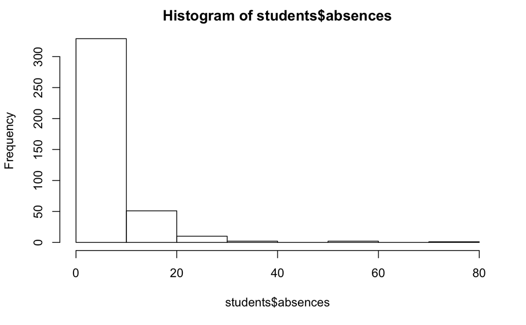

```r
# View a histogram of the absences variable
hist(students$absences)
```

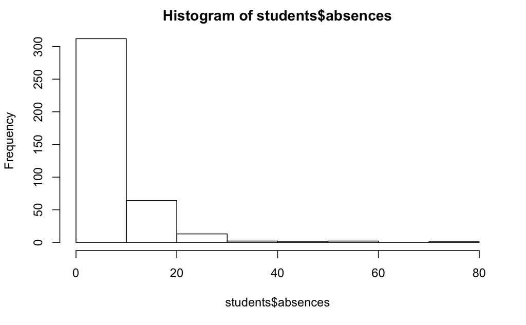

```r
# View a histogram of absences, but force zeros to be bucketed to the right of zero
hist(students$absences, right = FALSE)
```

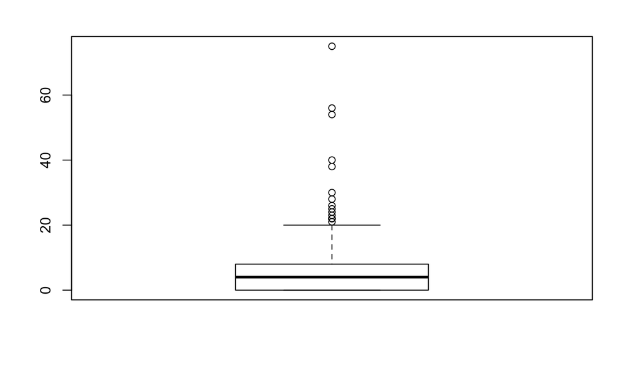

```r
# View a boxplot of absences
boxplot(students$absences)
```

Time to put it all together with the weather dataset

```r
weather <- readRDS("weather.rds")
head(weather)
```

|  | X | year | month | measure | X1 | X2 | X3 | X4 | X5 | X6 | X7 | X8 | X9 | X10 | X11 | X12 | X13 | X14 | X15 | X16 | X17 | X18 | X19 | X20 | X21 | X22 | X23 | X24 | X25 | … |
| --- | --- | --- | --- | --- | --- | --- | --- | --- | --- | --- | --- | --- | --- | --- | --- | --- | --- | --- | --- | --- | --- | --- | --- | --- | --- | --- | --- | --- | --- | --- |
| 1 | 1 | 2014 | 12 | Max.TemperatureF | 64 | 42 | 51 | 43 | 42 | 45 | 38 | 29 | 49 | 48 | 39 | 39 | 42 | 45 | 42 | 44 | 49 | 44 | 37 | 36 | 36 | 44 | 47 | 46 | 59 | … |
| 2 | 2 | 2014 | 12 | Mean.TemperatureF | 52 | 38 | 44 | 37 | 34 | 42 | 30 | 24 | 39 | 43 | 36 | 35 | 37 | 39 | 37 | 40 | 45 | 40 | 33 | 32 | 33 | 39 | 45 | 44 | 52 | … |
| 3 | 3 | 2014 | 12 | Min.TemperatureF | 39 | 33 | 37 | 30 | 26 | 38 | 21 | 18 | 29 | 38 | 32 | 31 | 32 | 33 | 32 | 35 | 41 | 36 | 29 | 27 | 30 | 33 | 42 | 41 | 44 | … |
| 4 | 4 | 2014 | 12 | Max.Dew.PointF | 46 | 40 | 49 | 24 | 37 | 45 | 36 | 28 | 49 | 45 | 37 | 28 | 28 | 29 | 33 | 42 | 46 | 34 | 25 | 30 | 30 | 39 | 45 | 46 | 58 | … |
| 5 | 5 | 2014 | 12 | MeanDew.PointF | 40 | 27 | 42 | 21 | 25 | 40 | 20 | 16 | 41 | 39 | 31 | 27 | 26 | 27 | 29 | 36 | 41 | 30 | 22 | 24 | 27 | 34 | 42 | 44 | 43 | … |
| 6 | 6 | 2014 | 12 | Min.DewpointF | 26 | 17 | 24 | 13 | 12 | 36 | -3 | 3 | 28 | 37 | 27 | 25 | 24 | 25 | 27 | 30 | 32 | 26 | 20 | 20 | 25 | 25 | 37 | 41 | 29 | … |

Get a feel for the data Before diving into our data cleaning routine, we must first understand the basic structure of the data. This involves looking at things like the class() of the data object to make sure it’s what we expect (generally a data.frame) in addition to checking its dimensions with dim() and the column names with names().

```r
# Verify that weather is a data.frame
class(weather)
```

```
[1] "data.frame"
```

```r
# Check the dimensions
dim(weather)
```

```
[1] 286  35
```

```r
# View the column names
names(weather)
```

```
 [1] "X"       "year"    "month"   "measure" "X1"      "X2"      "X3"      "X4"
 [9] "X5"      "X6"      "X7"      "X8"      "X9"      "X10"     "X11"     "X12"
[17] "X13"     "X14"     "X15"     "X16"     "X17"     "X18"     "X19"     "X20"
[25] "X21"     "X22"     "X23"     "X24"     "X25"     "X26"     "X27"     "X28"
[33] "X29"     "X30"     "X31"
```

Summarize the data Next up is to look at some summaries of the data. This is where functions like str(), glimpse() from dplyr, and summary() come in handy.

```r
# View the structure of the data
str(weather)
```

```
'data.frame':   286 obs. of  35 variables:
 $ X      : int  1 2 3 4 5 6 7 8 9 10 ...
 $ year   : int  2014 2014 2014 2014 2014 2014 2014 2014 2014 2014 ...
 $ month  : int  12 12 12 12 12 12 12 12 12 12 ...
 $ measure: chr  "Max.TemperatureF" "Mean.TemperatureF" "Min.TemperatureF" "Max.Dew.PointF" ...
 $ X1     : chr  "64" "52" "39" "46" ...
 $ X2     : chr  "42" "38" "33" "40" ...
 $ X3     : chr  "51" "44" "37" "49" ...
 $ X4     : chr  "43" "37" "30" "24" ...
 $ X5     : chr  "42" "34" "26" "37" ...
 $ X6     : chr  "45" "42" "38" "45" ...
 $ X7     : chr  "38" "30" "21" "36" ...
 $ X8     : chr  "29" "24" "18" "28" ...
 $ X9     : chr  "49" "39" "29" "49" ...
 $ X10    : chr  "48" "43" "38" "45" ...
```

[output cut: 21 more lines]

```r
# Load dplyr package
library(dplyr)
# Look at the structure using dplyr's glimpse()
glimpse(weather)
```

```
Observations: 286
Variables: 35
$ X       <int> 1, 2, 3, 4, 5, 6, 7, 8, 9, 10, 11, 12, 13, 14, 15, 16, 17, 18, 19, 20, ...
$ year    <int> 2014, 2014, 2014, 2014, 2014, 2014, 2014, 2014, 2014, 2014, 2014, 2014,...
$ month   <int> 12, 12, 12, 12, 12, 12, 12, 12, 12, 12, 12, 12, 12, 12, 12, 12, 12, 12,...
$ measure <chr> "Max.TemperatureF", "Mean.TemperatureF", "Min.TemperatureF", "Max.Dew.P...
$ X1      <chr> "64", "52", "39", "46", "40", "26", "74", "63", "52", "30.45", "30.13",...
$ X2      <chr> "42", "38", "33", "40", "27", "17", "92", "72", "51", "30.71", "30.59",...
$ X3      <chr> "51", "44", "37", "49", "42", "24", "100", "79", "57", "30.4", "30.07",...
$ X4      <chr> "43", "37", "30", "24", "21", "13", "69", "54", "39", "30.56", "30.33",...
$ X5      <chr> "42", "34", "26", "37", "25", "12", "85", "66", "47", "30.68", "30.59",...
$ X6      <chr> "45", "42", "38", "45", "40", "36", "100", "93", "85", "30.42", "30.24"...
$ X7      <chr> "38", "30", "21", "36", "20", "-3", "92", "61", "29", "30.69", "30.46",...
$ X8      <chr> "29", "24", "18", "28", "16", "3", "92", "70", "47", "30.77", "30.67", ...
$ X9      <chr> "49", "39", "29", "49", "41", "28", "100", "93", "86", "30.51", "30.04"...
```

[output cut: 22 more lines]

```r
# View a summary of the data
summary(weather)
```

```
       X               year          month          measure               X1
 Min.   :  1.00   Min.   :2014   Min.   : 1.000   Length:286         Length:286
 1st Qu.: 72.25   1st Qu.:2015   1st Qu.: 4.000   Class :character   Class :character
 Median :143.50   Median :2015   Median : 7.000   Mode  :character   Mode  :character
 Mean   :143.50   Mean   :2015   Mean   : 6.923
 3rd Qu.:214.75   3rd Qu.:2015   3rd Qu.:10.000
 Max.   :286.00   Max.   :2015   Max.   :12.000
      X2                 X3                 X4                 X5
 Length:286         Length:286         Length:286         Length:286
 Class :character   Class :character   Class :character   Class :character
 Mode  :character   Mode  :character   Mode  :character   Mode  :character



      X6                 X7                 X8                 X9
 Length:286         Length:286         Length:286         Length:286
 Class :character   Class :character   Class :character   Class :character
 Mode  :character   Mode  :character   Mode  :character   Mode  :character



     X10                X11                X12                X13
 Length:286         Length:286         Length:286         Length:286
 Class :character   Class :character   Class :character   Class :character
 Mode  :character   Mode  :character   Mode  :character   Mode  :character



     X14                X15                X16                X17
 Length:286         Length:286         Length:286         Length:286
 Class :character   Class :character   Class :character   Class :character
 Mode  :character   Mode  :character   Mode  :character   Mode  :character



     X18                X19                X20                X21
 Length:286         Length:286         Length:286         Length:286
 Class :character   Class :character   Class :character   Class :character
 Mode  :character   Mode  :character   Mode  :character   Mode  :character



     X22                X23                X24                X25
 Length:286         Length:286         Length:286         Length:286
 Class :character   Class :character   Class :character   Class :character
 Mode  :character   Mode  :character   Mode  :character   Mode  :character



     X26                X27                X28                X29
 Length:286         Length:286         Length:286         Length:286
 Class :character   Class :character   Class :character   Class :character
 Mode  :character   Mode  :character   Mode  :character   Mode  :character



     X30                X31
 Length:286         Length:286
 Class :character   Class :character
 Mode  :character   Mode  :character
```

Take a closer look After understanding the structure of the data and looking at some brief summaries, it often helps to preview the actual data. The functions head() and tail() allow you to view the top and bottom rows of the data, respectively. Recall you’ll be shown 6 rows by default, but you can alter this behavior with a second argument to the function.

```r
# View first 6 rows
head(weather)
```

|  | X | year | month | measure | X1 | X2 | X3 | X4 | X5 | X6 | X7 | X8 | X9 | X10 | X11 | X12 | X13 | X14 | X15 | X16 | X17 | X18 | X19 | X20 | X21 | X22 | X23 | X24 | X25 | … |
| --- | --- | --- | --- | --- | --- | --- | --- | --- | --- | --- | --- | --- | --- | --- | --- | --- | --- | --- | --- | --- | --- | --- | --- | --- | --- | --- | --- | --- | --- | --- |
| 1 | 1 | 2014 | 12 | Max.TemperatureF | 64 | 42 | 51 | 43 | 42 | 45 | 38 | 29 | 49 | 48 | 39 | 39 | 42 | 45 | 42 | 44 | 49 | 44 | 37 | 36 | 36 | 44 | 47 | 46 | 59 | … |
| 2 | 2 | 2014 | 12 | Mean.TemperatureF | 52 | 38 | 44 | 37 | 34 | 42 | 30 | 24 | 39 | 43 | 36 | 35 | 37 | 39 | 37 | 40 | 45 | 40 | 33 | 32 | 33 | 39 | 45 | 44 | 52 | … |
| 3 | 3 | 2014 | 12 | Min.TemperatureF | 39 | 33 | 37 | 30 | 26 | 38 | 21 | 18 | 29 | 38 | 32 | 31 | 32 | 33 | 32 | 35 | 41 | 36 | 29 | 27 | 30 | 33 | 42 | 41 | 44 | … |
| 4 | 4 | 2014 | 12 | Max.Dew.PointF | 46 | 40 | 49 | 24 | 37 | 45 | 36 | 28 | 49 | 45 | 37 | 28 | 28 | 29 | 33 | 42 | 46 | 34 | 25 | 30 | 30 | 39 | 45 | 46 | 58 | … |
| 5 | 5 | 2014 | 12 | MeanDew.PointF | 40 | 27 | 42 | 21 | 25 | 40 | 20 | 16 | 41 | 39 | 31 | 27 | 26 | 27 | 29 | 36 | 41 | 30 | 22 | 24 | 27 | 34 | 42 | 44 | 43 | … |
| 6 | 6 | 2014 | 12 | Min.DewpointF | 26 | 17 | 24 | 13 | 12 | 36 | -3 | 3 | 28 | 37 | 27 | 25 | 24 | 25 | 27 | 30 | 32 | 26 | 20 | 20 | 25 | 25 | 37 | 41 | 29 | … |

```r
# View first 15 rows
head(weather, n=15)
```

|  | X | year | month | measure | X1 | X2 | X3 | X4 | X5 | X6 | X7 | X8 | X9 | X10 | X11 | X12 | X13 | X14 | X15 | X16 | X17 | X18 | X19 | X20 | X21 | X22 | X23 | X24 | X25 | … |
| --- | --- | --- | --- | --- | --- | --- | --- | --- | --- | --- | --- | --- | --- | --- | --- | --- | --- | --- | --- | --- | --- | --- | --- | --- | --- | --- | --- | --- | --- | --- |
| 1 | 1 | 2014 | 12 | Max.TemperatureF | 64 | 42 | 51 | 43 | 42 | 45 | 38 | 29 | 49 | 48 | 39 | 39 | 42 | 45 | 42 | 44 | 49 | 44 | 37 | 36 | 36 | 44 | 47 | 46 | 59 | … |
| 2 | 2 | 2014 | 12 | Mean.TemperatureF | 52 | 38 | 44 | 37 | 34 | 42 | 30 | 24 | 39 | 43 | 36 | 35 | 37 | 39 | 37 | 40 | 45 | 40 | 33 | 32 | 33 | 39 | 45 | 44 | 52 | … |
| 3 | 3 | 2014 | 12 | Min.TemperatureF | 39 | 33 | 37 | 30 | 26 | 38 | 21 | 18 | 29 | 38 | 32 | 31 | 32 | 33 | 32 | 35 | 41 | 36 | 29 | 27 | 30 | 33 | 42 | 41 | 44 | … |
| 4 | 4 | 2014 | 12 | Max.Dew.PointF | 46 | 40 | 49 | 24 | 37 | 45 | 36 | 28 | 49 | 45 | 37 | 28 | 28 | 29 | 33 | 42 | 46 | 34 | 25 | 30 | 30 | 39 | 45 | 46 | 58 | … |
| 5 | 5 | 2014 | 12 | MeanDew.PointF | 40 | 27 | 42 | 21 | 25 | 40 | 20 | 16 | 41 | 39 | 31 | 27 | 26 | 27 | 29 | 36 | 41 | 30 | 22 | 24 | 27 | 34 | 42 | 44 | 43 | … |
| 6 | 6 | 2014 | 12 | Min.DewpointF | 26 | 17 | 24 | 13 | 12 | 36 | -3 | 3 | 28 | 37 | 27 | 25 | 24 | 25 | 27 | 30 | 32 | 26 | 20 | 20 | 25 | 25 | 37 | 41 | 29 | … |
| 7 | 7 | 2014 | 12 | Max.Humidity | 74 | 92 | 100 | 69 | 85 | 100 | 92 | 92 | 100 | 100 | 92 | 85 | 75 | 82 | 89 | 96 | 100 | 89 | 69 | 89 | 85 | 89 | 100 | 100 | 100 | … |
| 8 | 8 | 2014 | 12 | Mean.Humidity | 63 | 72 | 79 | 54 | 66 | 93 | 61 | 70 | 93 | 95 | 87 | 75 | 65 | 68 | 75 | 85 | 85 | 73 | 63 | 79 | 77 | 79 | 91 | 98 | 75 | … |
| 9 | 9 | 2014 | 12 | Min.Humidity | 52 | 51 | 57 | 39 | 47 | 85 | 29 | 47 | 86 | 89 | 82 | 64 | 55 | 53 | 60 | 73 | 70 | 57 | 56 | 69 | 69 | 69 | 82 | 96 | 49 | … |
| 10 | 10 | 2014 | 12 | Max.Sea.Level.PressureIn | 30.45 | 30.71 | 30.4 | 30.56 | 30.68 | 30.42 | 30.69 | 30.77 | 30.51 | 29.58 | 29.81 | 29.88 | 29.86 | 29.91 | 30.15 | 30.17 | 29.91 | 29.87 | 30.15 | 30.31 | 30.37 | 30.4 | 30.31 | 30.13 | 29.96 | … |

[output cut: 5 more lines]

```r
# View the last 6 rows
tail(weather)
```

|  | X | year | month | measure | X1 | X2 | X3 | X4 | X5 | X6 | X7 | X8 | X9 | X10 | X11 | X12 | X13 | X14 | X15 | X16 | X17 | X18 | X19 | X20 | X21 | X22 | X23 | X24 | X25 | … |
| --- | --- | --- | --- | --- | --- | --- | --- | --- | --- | --- | --- | --- | --- | --- | --- | --- | --- | --- | --- | --- | --- | --- | --- | --- | --- | --- | --- | --- | --- | --- |
| 281 | 281 | 2015 | 12 | Mean.Wind.SpeedMPH | 6 | NA | NA | NA | NA | NA | NA | NA | NA | NA | NA | NA | NA | NA | NA | NA | NA | NA | NA | NA | NA | NA | NA | NA | NA | … |
| 282 | 282 | 2015 | 12 | Max.Gust.SpeedMPH | 17 | NA | NA | NA | NA | NA | NA | NA | NA | NA | NA | NA | NA | NA | NA | NA | NA | NA | NA | NA | NA | NA | NA | NA | NA | … |
| 283 | 283 | 2015 | 12 | PrecipitationIn | 0.14 | NA | NA | NA | NA | NA | NA | NA | NA | NA | NA | NA | NA | NA | NA | NA | NA | NA | NA | NA | NA | NA | NA | NA | NA | … |
| 284 | 284 | 2015 | 12 | CloudCover | 7 | NA | NA | NA | NA | NA | NA | NA | NA | NA | NA | NA | NA | NA | NA | NA | NA | NA | NA | NA | NA | NA | NA | NA | NA | … |
| 285 | 285 | 2015 | 12 | Events | Rain | NA | NA | NA | NA | NA | NA | NA | NA | NA | NA | NA | NA | NA | NA | NA | NA | NA | NA | NA | NA | NA | NA | NA | NA | … |
| 286 | 286 | 2015 | 12 | WindDirDegrees | 109 | NA | NA | NA | NA | NA | NA | NA | NA | NA | NA | NA | NA | NA | NA | NA | NA | NA | NA | NA | NA | NA | NA | NA | NA | … |

```r
# View the last 10 rows
tail(weather, n=10)
```

|  | X | year | month | measure | X1 | X2 | X3 | X4 | X5 | X6 | X7 | X8 | X9 | X10 | X11 | X12 | X13 | X14 | X15 | X16 | X17 | X18 | X19 | X20 | X21 | X22 | X23 | X24 | X25 | … |
| --- | --- | --- | --- | --- | --- | --- | --- | --- | --- | --- | --- | --- | --- | --- | --- | --- | --- | --- | --- | --- | --- | --- | --- | --- | --- | --- | --- | --- | --- | --- |
| 277 | 277 | 2015 | 12 | Max.VisibilityMiles | 10 | NA | NA | NA | NA | NA | NA | NA | NA | NA | NA | NA | NA | NA | NA | NA | NA | NA | NA | NA | NA | NA | NA | NA | NA | … |
| 278 | 278 | 2015 | 12 | Mean.VisibilityMiles | 8 | NA | NA | NA | NA | NA | NA | NA | NA | NA | NA | NA | NA | NA | NA | NA | NA | NA | NA | NA | NA | NA | NA | NA | NA | … |
| 279 | 279 | 2015 | 12 | Min.VisibilityMiles | 1 | NA | NA | NA | NA | NA | NA | NA | NA | NA | NA | NA | NA | NA | NA | NA | NA | NA | NA | NA | NA | NA | NA | NA | NA | … |
| 280 | 280 | 2015 | 12 | Max.Wind.SpeedMPH | 15 | NA | NA | NA | NA | NA | NA | NA | NA | NA | NA | NA | NA | NA | NA | NA | NA | NA | NA | NA | NA | NA | NA | NA | NA | … |
| 281 | 281 | 2015 | 12 | Mean.Wind.SpeedMPH | 6 | NA | NA | NA | NA | NA | NA | NA | NA | NA | NA | NA | NA | NA | NA | NA | NA | NA | NA | NA | NA | NA | NA | NA | NA | … |
| 282 | 282 | 2015 | 12 | Max.Gust.SpeedMPH | 17 | NA | NA | NA | NA | NA | NA | NA | NA | NA | NA | NA | NA | NA | NA | NA | NA | NA | NA | NA | NA | NA | NA | NA | NA | … |
| 283 | 283 | 2015 | 12 | PrecipitationIn | 0.14 | NA | NA | NA | NA | NA | NA | NA | NA | NA | NA | NA | NA | NA | NA | NA | NA | NA | NA | NA | NA | NA | NA | NA | NA | … |
| 284 | 284 | 2015 | 12 | CloudCover | 7 | NA | NA | NA | NA | NA | NA | NA | NA | NA | NA | NA | NA | NA | NA | NA | NA | NA | NA | NA | NA | NA | NA | NA | NA | … |
| 285 | 285 | 2015 | 12 | Events | Rain | NA | NA | NA | NA | NA | NA | NA | NA | NA | NA | NA | NA | NA | NA | NA | NA | NA | NA | NA | NA | NA | NA | NA | NA | … |
| 286 | 286 | 2015 | 12 | WindDirDegrees | 109 | NA | NA | NA | NA | NA | NA | NA | NA | NA | NA | NA | NA | NA | NA | NA | NA | NA | NA | NA | NA | NA | NA | NA | NA | … |

Column names are values The weather dataset suffers from one of the five most common symptoms of messy data: column names are values. In particular, the column names X1-X31 represent days of the month, which should really be values of a new variable called day.

The tidyr package provides the gather() function for exactly this scenario. To remind you of how it works, we’ve loaded a small dataset called df in your workspace. Give the following a try in the console before attempting the instructions below.

gather(df, time, val, t1:t3) Notice that gather() allows you to select multiple columns to be gathered by using the : operator.

```r
# Load the tidyr package
library(tidyr)
# Gather the columns
weather2 <- gather(weather, day, value, X1:X31, na.rm = TRUE)
# View the head
head(weather2)
```

|  | X | year | month | measure | day | value |
| --- | --- | --- | --- | --- | --- | --- |
| 1 | 1 | 2014 | 12 | Max.TemperatureF | X1 | 64 |
| 2 | 2 | 2014 | 12 | Mean.TemperatureF | X1 | 52 |
| 3 | 3 | 2014 | 12 | Min.TemperatureF | X1 | 39 |
| 4 | 4 | 2014 | 12 | Max.Dew.PointF | X1 | 46 |
| 5 | 5 | 2014 | 12 | MeanDew.PointF | X1 | 40 |
| 6 | 6 | 2014 | 12 | Min.DewpointF | X1 | 26 |

Values are variable names Our data suffer from a second common symptom of messy data: values are variable names. Specifically, values in the measure column should be variables (i.e. column names) in our dataset.

The spread() function from tidyr is designed to help with this. To remind you of how this function works, we’ve loaded another small dataset called df2 (which is the result of applying gather() to the original df from last exercise). Give the following a try before attempting the instructions below.

spread(df2, time, val) Note how the values of the time column now become column names.

```r
## The tidyr package is already loaded
# First remove column of row names
weather2 <- weather2[, -1]
# Spread the data
weather3 <- spread(weather2, measure, value)
# View the head
head(weather3)
```

|  | year | month | day | CloudCover | Events | Max.Dew.PointF | Max.Gust.SpeedMPH | Max.Humidity | Max.Sea.Level.PressureIn | Max.TemperatureF | Max.VisibilityMiles | Max.Wind.SpeedMPH | Mean.Humidity | Mean.Sea.Level.PressureIn | Mean.TemperatureF | Mean.VisibilityMiles | Mean.Wind.SpeedMPH | MeanDew.PointF | Min.DewpointF | Min.Humidity | Min.Sea.Level.PressureIn | Min.TemperatureF | Min.VisibilityMiles | PrecipitationIn | WindDirDegrees |
| --- | --- | --- | --- | --- | --- | --- | --- | --- | --- | --- | --- | --- | --- | --- | --- | --- | --- | --- | --- | --- | --- | --- | --- | --- | --- |
| 1 | 2014 | 12 | X1 | 6 | Rain | 46 | 29 | 74 | 30.45 | 64 | 10 | 22 | 63 | 30.13 | 52 | 10 | 13 | 40 | 26 | 52 | 30.01 | 39 | 10 | 0.01 | 268 |
| 2 | 2014 | 12 | X10 | 8 | Rain | 45 | 29 | 100 | 29.58 | 48 | 10 | 23 | 95 | 29.5 | 43 | 3 | 13 | 39 | 37 | 89 | 29.43 | 38 | 1 | 0.28 | 357 |
| 3 | 2014 | 12 | X11 | 8 | Rain-Snow | 37 | 28 | 92 | 29.81 | 39 | 10 | 21 | 87 | 29.61 | 36 | 7 | 13 | 31 | 27 | 82 | 29.44 | 32 | 1 | 0.02 | 230 |
| 4 | 2014 | 12 | X12 | 7 | Snow | 28 | 21 | 85 | 29.88 | 39 | 10 | 16 | 75 | 29.85 | 35 | 10 | 11 | 27 | 25 | 64 | 29.81 | 31 | 7 | T | 286 |
| 5 | 2014 | 12 | X13 | 5 |  | 28 | 23 | 75 | 29.86 | 42 | 10 | 17 | 65 | 29.82 | 37 | 10 | 12 | 26 | 24 | 55 | 29.78 | 32 | 10 | T | 298 |
| 6 | 2014 | 12 | X14 | 4 |  | 29 | 20 | 82 | 29.91 | 45 | 10 | 15 | 68 | 29.83 | 39 | 10 | 10 | 27 | 25 | 53 | 29.78 | 33 | 10 | 0.00 | 306 |

Clean up dates Now that the weather dataset adheres to tidy data principles, the next step is to prepare it for analysis. We’ll start by combining the year, month, and day columns and recoding the resulting character column as a date. We can use a combination of base R, stringr, and lubridate to accomplish this task.

```r
## tidyr and dplyr are already loaded
# Load the stringr and lubridate packages
#library(stringr)
#library(lubridate)
# Remove X's from day column
weather3$day <- str_replace(weather3$day, "X","")
# Unite the year, month, and day columns
weather4 <- unite(weather3, date, year, month, day, sep = "-")
# Convert date column to proper date format using lubridates's ymd()
weather4$date <- ymd(weather4$date)
# Rearrange columns using dplyr's select()
weather5 <- select(weather4, date, Events, CloudCover:WindDirDegrees)
# View the head of weather5
head(weather5)
```

|  | date | Events | CloudCover | Max.Dew.PointF | Max.Gust.SpeedMPH | Max.Humidity | Max.Sea.Level.PressureIn | Max.TemperatureF | Max.VisibilityMiles | Max.Wind.SpeedMPH | Mean.Humidity | Mean.Sea.Level.PressureIn | Mean.TemperatureF | Mean.VisibilityMiles | Mean.Wind.SpeedMPH | MeanDew.PointF | Min.DewpointF | Min.Humidity | Min.Sea.Level.PressureIn | Min.TemperatureF | Min.VisibilityMiles | PrecipitationIn | WindDirDegrees |
| --- | --- | --- | --- | --- | --- | --- | --- | --- | --- | --- | --- | --- | --- | --- | --- | --- | --- | --- | --- | --- | --- | --- | --- |
| 1 | 2014-12-01 | Rain | 6 | 46 | 29 | 74 | 30.45 | 64 | 10 | 22 | 63 | 30.13 | 52 | 10 | 13 | 40 | 26 | 52 | 30.01 | 39 | 10 | 0.01 | 268 |
| 2 | 2014-12-10 | Rain | 8 | 45 | 29 | 100 | 29.58 | 48 | 10 | 23 | 95 | 29.5 | 43 | 3 | 13 | 39 | 37 | 89 | 29.43 | 38 | 1 | 0.28 | 357 |
| 3 | 2014-12-11 | Rain-Snow | 8 | 37 | 28 | 92 | 29.81 | 39 | 10 | 21 | 87 | 29.61 | 36 | 7 | 13 | 31 | 27 | 82 | 29.44 | 32 | 1 | 0.02 | 230 |
| 4 | 2014-12-12 | Snow | 7 | 28 | 21 | 85 | 29.88 | 39 | 10 | 16 | 75 | 29.85 | 35 | 10 | 11 | 27 | 25 | 64 | 29.81 | 31 | 7 | T | 286 |
| 5 | 2014-12-13 |  | 5 | 28 | 23 | 75 | 29.86 | 42 | 10 | 17 | 65 | 29.82 | 37 | 10 | 12 | 26 | 24 | 55 | 29.78 | 32 | 10 | T | 298 |
| 6 | 2014-12-14 |  | 4 | 29 | 20 | 82 | 29.91 | 45 | 10 | 15 | 68 | 29.83 | 39 | 10 | 10 | 27 | 25 | 53 | 29.78 | 33 | 10 | 0.00 | 306 |

A closer look at column types It’s important for analysis that variables are coded appropriately. This is not yet the case with our weather data. Recall that functions such as as.numeric() and as.character() can be used to coerce variables into different types.

It’s important to keep in mind that coercions are not always successful, particularly if there’s some data in a column that you don’t expect. For example, the following will cause problems:

as.numeric(c(4, 6.44, “some string”, 222)) If you run the code above in the console, you’ll get a warning message saying that R introduced an NA in the process of coercing to numeric. This is because it doesn’t know how to make a number out of a string (“some string”). Watch out for this in our weather data!

```r
# View the structure of weather5
str(weather5)
```

```
'data.frame':   366 obs. of  23 variables:
 $ date                     : Date, format: "2014-12-01" "2014-12-10" "2014-12-11" ...
 $ Events                   : chr  "Rain" "Rain" "Rain-Snow" "Snow" ...
 $ CloudCover               : chr  "6" "8" "8" "7" ...
 $ Max.Dew.PointF           : chr  "46" "45" "37" "28" ...
 $ Max.Gust.SpeedMPH        : chr  "29" "29" "28" "21" ...
 $ Max.Humidity             : chr  "74" "100" "92" "85" ...
 $ Max.Sea.Level.PressureIn : chr  "30.45" "29.58" "29.81" "29.88" ...
 $ Max.TemperatureF         : chr  "64" "48" "39" "39" ...
 $ Max.VisibilityMiles      : chr  "10" "10" "10" "10" ...
 $ Max.Wind.SpeedMPH        : chr  "22" "23" "21" "16" ...
 $ Mean.Humidity            : chr  "63" "95" "87" "75" ...
 $ Mean.Sea.Level.PressureIn: chr  "30.13" "29.5" "29.61" "29.85" ...
 $ Mean.TemperatureF        : chr  "52" "43" "36" "35" ...
 $ Mean.VisibilityMiles     : chr  "10" "3" "7" "10" ...
 $ Mean.Wind.SpeedMPH       : chr  "13" "13" "13" "11" ...
 $ MeanDew.PointF           : chr  "40" "39" "31" "27" ...
 $ Min.DewpointF            : chr  "26" "37" "27" "25" ...
 $ Min.Humidity             : chr  "52" "89" "82" "64" ...
 $ Min.Sea.Level.PressureIn : chr  "30.01" "29.43" "29.44" "29.81" ...
 $ Min.TemperatureF         : chr  "39" "38" "32" "31" ...
 $ Min.VisibilityMiles      : chr  "10" "1" "1" "7" ...
 $ PrecipitationIn          : chr  "0.01" "0.28" "0.02" "T" ...
 $ WindDirDegrees           : chr  "268" "357" "230" "286" ...
```

```r
# Examine the first 20 rows of weather5. Are most of the characters numeric?
head(weather5, n=20)
```

|  | date | Events | CloudCover | Max.Dew.PointF | Max.Gust.SpeedMPH | Max.Humidity | Max.Sea.Level.PressureIn | Max.TemperatureF | Max.VisibilityMiles | Max.Wind.SpeedMPH | Mean.Humidity | Mean.Sea.Level.PressureIn | Mean.TemperatureF | Mean.VisibilityMiles | Mean.Wind.SpeedMPH | MeanDew.PointF | Min.DewpointF | Min.Humidity | Min.Sea.Level.PressureIn | Min.TemperatureF | Min.VisibilityMiles | PrecipitationIn | WindDirDegrees |
| --- | --- | --- | --- | --- | --- | --- | --- | --- | --- | --- | --- | --- | --- | --- | --- | --- | --- | --- | --- | --- | --- | --- | --- |
| 1 | 2014-12-01 | Rain | 6 | 46 | 29 | 74 | 30.45 | 64 | 10 | 22 | 63 | 30.13 | 52 | 10 | 13 | 40 | 26 | 52 | 30.01 | 39 | 10 | 0.01 | 268 |
| 2 | 2014-12-10 | Rain | 8 | 45 | 29 | 100 | 29.58 | 48 | 10 | 23 | 95 | 29.5 | 43 | 3 | 13 | 39 | 37 | 89 | 29.43 | 38 | 1 | 0.28 | 357 |
| 3 | 2014-12-11 | Rain-Snow | 8 | 37 | 28 | 92 | 29.81 | 39 | 10 | 21 | 87 | 29.61 | 36 | 7 | 13 | 31 | 27 | 82 | 29.44 | 32 | 1 | 0.02 | 230 |
| 4 | 2014-12-12 | Snow | 7 | 28 | 21 | 85 | 29.88 | 39 | 10 | 16 | 75 | 29.85 | 35 | 10 | 11 | 27 | 25 | 64 | 29.81 | 31 | 7 | T | 286 |
| 5 | 2014-12-13 |  | 5 | 28 | 23 | 75 | 29.86 | 42 | 10 | 17 | 65 | 29.82 | 37 | 10 | 12 | 26 | 24 | 55 | 29.78 | 32 | 10 | T | 298 |
| 6 | 2014-12-14 |  | 4 | 29 | 20 | 82 | 29.91 | 45 | 10 | 15 | 68 | 29.83 | 39 | 10 | 10 | 27 | 25 | 53 | 29.78 | 33 | 10 | 0.00 | 306 |
| 7 | 2014-12-15 |  | 2 | 33 | 21 | 89 | 30.15 | 42 | 10 | 15 | 75 | 30.05 | 37 | 10 | 6 | 29 | 27 | 60 | 29.91 | 32 | 10 | 0.00 | 324 |
| 8 | 2014-12-16 | Rain | 8 | 42 | 10 | 96 | 30.17 | 44 | 10 | 8 | 85 | 30.09 | 40 | 9 | 4 | 36 | 30 | 73 | 29.92 | 35 | 5 | T | 79 |
| 9 | 2014-12-17 | Rain | 8 | 46 | 26 | 100 | 29.91 | 49 | 10 | 20 | 85 | 29.75 | 45 | 6 | 11 | 41 | 32 | 70 | 29.69 | 41 | 1 | 0.43 | 311 |
| 10 | 2014-12-18 | Rain | 7 | 34 | 30 | 89 | 29.87 | 44 | 10 | 23 | 73 | 29.78 | 40 | 10 | 14 | 30 | 26 | 57 | 29.71 | 36 | 10 | 0.01 | 281 |

[output cut: 10 more lines]

```r
# See what happens if we try to convert PrecipitationIn to numeric
as.numeric(weather5$PrecipitationIn)
```

```
NAs introduced by coercion
```

```
  [1] 0.01 0.28 0.02   NA   NA 0.00 0.00   NA 0.43 0.01 0.00 0.10   NA   NA 0.05 0.25 0.56
 [18] 0.14 0.00 0.00 0.01 0.00 0.44 0.00 0.00 0.00 0.11 1.09 0.13 0.03 2.90 0.00 0.00 0.00
 [35] 0.20 0.00   NA 0.12 0.00 0.00 0.15 0.00 0.00 0.00 0.00   NA 0.00 0.71 0.00 0.10 0.95
 [52] 0.01   NA 0.62 0.06 0.05 0.57 0.00 0.02   NA 0.00 0.01 0.00 0.05 0.01 0.03 0.00 0.23
 [69] 0.39 0.00 0.02 0.01 0.06 0.78 0.00 0.17 0.11 0.00   NA 0.07 0.02 0.00 0.00 0.00 0.00
 [86] 0.09   NA 0.07 0.37 0.88 0.17 0.06 0.01 0.00 0.00 0.80 0.27 0.00 0.14 0.00 0.00 0.01
[103] 0.05 0.09 0.00 0.00 0.00 0.04 0.80 0.21 0.12 0.00 0.26   NA 0.00 0.02   NA 0.00 0.00
[120]   NA 0.00 0.00 0.09 0.00 0.00 0.00 0.01 0.00 0.00 0.06 0.00 0.00 0.00 0.61 0.54   NA
[137] 0.00   NA 0.00 0.00 0.10 0.07 0.00 0.03 0.00 0.39 0.00 0.00 0.03 0.26 0.09 0.00 0.00
[154] 0.00 0.02 0.00 0.00 0.00   NA 0.00 0.00 0.27 0.00 0.00 0.00   NA 0.00 0.00   NA 0.00
[171] 0.00   NA 0.00 0.00 0.00 0.91 0.00 0.02 0.00 0.00 0.00 0.00 0.38 0.00 0.00 0.00   NA
[188] 0.00 0.40   NA 0.00 0.00 0.00 0.74 0.04 1.72 0.00 0.01 0.00 0.00   NA 0.20 1.43   NA
[205] 0.00 0.00 0.00   NA 0.09 0.00   NA   NA 0.50 1.12 0.00 0.00 0.00 0.03   NA 0.00   NA
[222] 0.14   NA 0.00   NA   NA 0.00 0.00 0.01 0.00   NA 0.06 0.00 0.00 0.00 0.02 0.00   NA
[239] 0.00 0.00 0.02   NA 0.15   NA 0.00 0.83 0.00 0.00 0.00 0.08 0.00 0.00 0.14 0.00 0.00
[256] 0.00 0.63   NA 0.02   NA 0.00   NA 0.00 0.00 0.00 0.00 0.00 0.00 0.49 0.00 0.00 0.00
[273] 0.00 0.00 0.00 0.17 0.66 0.01 0.38 0.00 0.00 0.00 0.00 0.00 0.00 0.00   NA 0.00 0.00
[290] 0.00 0.00 0.00 0.00 0.00 0.00 0.04 0.01 2.46   NA 0.00 0.00 0.00 0.20 0.00   NA 0.00
[307] 0.00 0.00 0.12 0.00 0.00   NA   NA   NA 0.00 0.08   NA 0.07   NA 0.00 0.00 0.03 0.00
[324] 0.00 0.36 0.73 0.01 0.00 0.00 0.00 0.00 0.00 0.00 0.00 0.34   NA 0.07 0.54 0.04 0.01
[341] 0.00 0.00 0.00 0.00 0.00   NA 0.00 0.86 0.00 0.30 0.04 0.00 0.00 0.00 0.00 0.21 0.00
[358] 0.00 0.00 0.00 0.00 0.00 0.00 0.00 0.00 0.14
```

Column type conversions As you saw in the last exercise, “T” was used to denote a trace amount (i.e. too small to be accurately measured) of precipitation in the PrecipitationIn column. In order to coerce this column to numeric, you’ll need to deal with this somehow. To keep things simple, we will just replace “T” with the number zero.

```r
## The dplyr and stringr packages are already loaded
# Replace T with 0 (T = trace)
weather5$PrecipitationIn <- str_replace(weather5$PrecipitationIn, "T", "0")
# Convert characters to numerics
weather6 <- mutate_each(weather5, funs(as.numeric), CloudCover:WindDirDegrees)
```

```
`mutate_each()` is deprecated.
Use `mutate_all()`, `mutate_at()` or `mutate_if()` instead.
To map `funs` over a selection of variables, use `mutate_at()`
```

```r
# Look at result
str(weather6)
```

```
'data.frame':   366 obs. of  23 variables:
 $ date                     : Date, format: "2014-12-01" "2014-12-10" "2014-12-11" ...
 $ Events                   : chr  "Rain" "Rain" "Rain-Snow" "Snow" ...
 $ CloudCover               : num  6 8 8 7 5 4 2 8 8 7 ...
 $ Max.Dew.PointF           : num  46 45 37 28 28 29 33 42 46 34 ...
 $ Max.Gust.SpeedMPH        : num  29 29 28 21 23 20 21 10 26 30 ...
 $ Max.Humidity             : num  74 100 92 85 75 82 89 96 100 89 ...
 $ Max.Sea.Level.PressureIn : num  30.4 29.6 29.8 29.9 29.9 ...
 $ Max.TemperatureF         : num  64 48 39 39 42 45 42 44 49 44 ...
 $ Max.VisibilityMiles      : num  10 10 10 10 10 10 10 10 10 10 ...
 $ Max.Wind.SpeedMPH        : num  22 23 21 16 17 15 15 8 20 23 ...
 $ Mean.Humidity            : num  63 95 87 75 65 68 75 85 85 73 ...
 $ Mean.Sea.Level.PressureIn: num  30.1 29.5 29.6 29.9 29.8 ...
 $ Mean.TemperatureF        : num  52 43 36 35 37 39 37 40 45 40 ...
 $ Mean.VisibilityMiles     : num  10 3 7 10 10 10 10 9 6 10 ...
 $ Mean.Wind.SpeedMPH       : num  13 13 13 11 12 10 6 4 11 14 ...
 $ MeanDew.PointF           : num  40 39 31 27 26 27 29 36 41 30 ...
 $ Min.DewpointF            : num  26 37 27 25 24 25 27 30 32 26 ...
 $ Min.Humidity             : num  52 89 82 64 55 53 60 73 70 57 ...
 $ Min.Sea.Level.PressureIn : num  30 29.4 29.4 29.8 29.8 ...
 $ Min.TemperatureF         : num  39 38 32 31 32 33 32 35 41 36 ...
 $ Min.VisibilityMiles      : num  10 1 1 7 10 10 10 5 1 10 ...
 $ PrecipitationIn          : num  0.01 0.28 0.02 0 0 0 0 0 0.43 0.01 ...
 $ WindDirDegrees           : num  268 357 230 286 298 306 324 79 311 281 ...
```

Find missing values Before dealing with missing values in the data, it’s important to find them and figure out why they exist in the first place. If your dataset is too big to look at all at once, like it is here, remember you can use sum() and is.na() to quickly size up the situation by counting the number of NA values.

The summary() function may also come in handy for identifying which variables contain the missing values. Finally, the which() function is useful for locating the missing values within a particular column.

```r
# Count missing values
sum(is.na(weather6))
```

```
[1] 6
```

```r
# Find missing values
summary(weather6)
```

```
      date               Events            CloudCover    Max.Dew.PointF  Max.Gust.SpeedMPH
 Min.   :2014-12-01   Length:366         Min.   :0.000   Min.   :-6.00   Min.   : 0.00
 1st Qu.:2015-03-02   Class :character   1st Qu.:3.000   1st Qu.:32.00   1st Qu.:21.00
 Median :2015-06-01   Mode  :character   Median :5.000   Median :47.50   Median :25.50
 Mean   :2015-06-01                      Mean   :4.708   Mean   :45.48   Mean   :26.99
 3rd Qu.:2015-08-31                      3rd Qu.:7.000   3rd Qu.:61.00   3rd Qu.:31.25
 Max.   :2015-12-01                      Max.   :8.000   Max.   :75.00   Max.   :94.00
                                                                         NA's   :6
  Max.Humidity     Max.Sea.Level.PressureIn Max.TemperatureF Max.VisibilityMiles
 Min.   :  39.00   Min.   :29.58            Min.   :18.00    Min.   : 2.000
 1st Qu.:  73.25   1st Qu.:30.00            1st Qu.:42.00    1st Qu.:10.000
 Median :  86.00   Median :30.14            Median :60.00    Median :10.000
 Mean   :  85.69   Mean   :30.16            Mean   :58.93    Mean   : 9.907
 3rd Qu.:  93.00   3rd Qu.:30.31            3rd Qu.:76.00    3rd Qu.:10.000
 Max.   :1000.00   Max.   :30.88            Max.   :96.00    Max.   :10.000

 Max.Wind.SpeedMPH Mean.Humidity   Mean.Sea.Level.PressureIn Mean.TemperatureF
 Min.   : 8.00     Min.   :28.00   Min.   :29.49             Min.   : 8.00
 1st Qu.:16.00     1st Qu.:56.00   1st Qu.:29.87             1st Qu.:36.25
 Median :20.00     Median :66.00   Median :30.03             Median :53.50
 Mean   :20.62     Mean   :66.02   Mean   :30.04             Mean   :51.40
 3rd Qu.:24.00     3rd Qu.:76.75   3rd Qu.:30.19             3rd Qu.:68.00
 Max.   :38.00     Max.   :98.00   Max.   :30.77             Max.   :84.00

 Mean.VisibilityMiles Mean.Wind.SpeedMPH MeanDew.PointF   Min.DewpointF     Min.Humidity
 Min.   :-1.000       Min.   : 4.00      Min.   :-11.00   Min.   :-18.00   Min.   :16.00
 1st Qu.: 8.000       1st Qu.: 8.00      1st Qu.: 24.00   1st Qu.: 16.25   1st Qu.:35.00
 Median :10.000       Median :10.00      Median : 41.00   Median : 35.00   Median :46.00
 Mean   : 8.861       Mean   :10.68      Mean   : 38.96   Mean   : 32.25   Mean   :48.31
 3rd Qu.:10.000       3rd Qu.:13.00      3rd Qu.: 56.00   3rd Qu.: 51.00   3rd Qu.:60.00
 Max.   :10.000       Max.   :22.00      Max.   : 71.00   Max.   : 68.00   Max.   :96.00

 Min.Sea.Level.PressureIn Min.TemperatureF Min.VisibilityMiles PrecipitationIn
 Min.   :29.16            Min.   :-3.00    Min.   : 0.000      Min.   :0.0000
 1st Qu.:29.76            1st Qu.:30.00    1st Qu.: 2.000      1st Qu.:0.0000
 Median :29.94            Median :46.00    Median :10.000      Median :0.0000
 Mean   :29.93            Mean   :43.33    Mean   : 6.716      Mean   :0.1016
 3rd Qu.:30.09            3rd Qu.:60.00    3rd Qu.:10.000      3rd Qu.:0.0400
 Max.   :30.64            Max.   :74.00    Max.   :10.000      Max.   :2.9000

 WindDirDegrees
 Min.   :  1.0
 1st Qu.:113.0
 Median :222.0
 Mean   :200.1
 3rd Qu.:275.0
 Max.   :360.0
```

```r
# Find indices of NAs in Max.Gust.SpeedMPH
ind <- which(is.na(weather6$Max.Gust.SpeedMPH))
# Look at the full rows for records missing Max.Gust.SpeedMPH
weather6[ind, ]
```

|  | date | Events | CloudCover | Max.Dew.PointF | Max.Gust.SpeedMPH | Max.Humidity | Max.Sea.Level.PressureIn | Max.TemperatureF | Max.VisibilityMiles | Max.Wind.SpeedMPH | Mean.Humidity | Mean.Sea.Level.PressureIn | Mean.TemperatureF | Mean.VisibilityMiles | Mean.Wind.SpeedMPH | MeanDew.PointF | Min.DewpointF | Min.Humidity | Min.Sea.Level.PressureIn | Min.TemperatureF | Min.VisibilityMiles | PrecipitationIn | WindDirDegrees |
| --- | --- | --- | --- | --- | --- | --- | --- | --- | --- | --- | --- | --- | --- | --- | --- | --- | --- | --- | --- | --- | --- | --- | --- |
| 161 | 2015-05-18 | Fog | 6 | 52 | NA | 100 | 30.30 | 58 | 10 | 16 | 79 | 30.23 | 54 | 8 | 10 | 48 | 43 | 57 | 30.12 | 49 | 0 | 0 | 72 |
| 205 | 2015-06-03 |  | 7 | 48 | NA | 93 | 30.31 | 56 | 10 | 14 | 82 | 30.24 | 52 | 10 | 7 | 45 | 43 | 71 | 30.19 | 47 | 10 | 0 | 90 |
| 273 | 2015-08-08 |  | 4 | 61 | NA | 87 | 30.02 | 76 | 10 | 14 | 68 | 29.99 | 69 | 10 | 6 | 57 | 54 | 49 | 29.95 | 61 | 10 | 0 | 45 |
| 275 | 2015-09-01 |  | 1 | 63 | NA | 78 | 30.06 | 79 | 10 | 15 | 65 | 30.02 | 74 | 10 | 9 | 62 | 59 | 52 | 29.96 | 69 | 10 | 0 | 54 |
| 308 | 2015-10-12 |  | 0 | 56 | NA | 89 | 29.86 | 76 | 10 | 15 | 65 | 29.80 | 64 | 10 | 8 | 51 | 48 | 41 | 29.74 | 51 | 10 | 0 | 199 |
| 358 | 2015-11-03 |  | 1 | 44 | NA | 82 | 30.25 | 73 | 10 | 16 | 57 | 30.13 | 60 | 10 | 8 | 42 | 40 | 31 | 30.06 | 47 | 10 | 0 | 281 |

An obvious error Besides missing values, we want to know if there are values in the data that are too extreme or bizarre to be plausible. A great way to start the search for these values is with summary().

Once implausible values are identified, they must be dealt with in an intelligent and informed way. Sometimes the best way forward is obvious and other times it may require some research and/or discussions with the original collectors of the data.

```r
# Review distributions for all variables
summary(weather6)
```

```
      date               Events            CloudCover    Max.Dew.PointF  Max.Gust.SpeedMPH
 Min.   :2014-12-01   Length:366         Min.   :0.000   Min.   :-6.00   Min.   : 0.00
 1st Qu.:2015-03-02   Class :character   1st Qu.:3.000   1st Qu.:32.00   1st Qu.:21.00
 Median :2015-06-01   Mode  :character   Median :5.000   Median :47.50   Median :25.50
 Mean   :2015-06-01                      Mean   :4.708   Mean   :45.48   Mean   :26.99
 3rd Qu.:2015-08-31                      3rd Qu.:7.000   3rd Qu.:61.00   3rd Qu.:31.25
 Max.   :2015-12-01                      Max.   :8.000   Max.   :75.00   Max.   :94.00
                                                                         NA's   :6
  Max.Humidity     Max.Sea.Level.PressureIn Max.TemperatureF Max.VisibilityMiles
 Min.   :  39.00   Min.   :29.58            Min.   :18.00    Min.   : 2.000
 1st Qu.:  73.25   1st Qu.:30.00            1st Qu.:42.00    1st Qu.:10.000
 Median :  86.00   Median :30.14            Median :60.00    Median :10.000
 Mean   :  85.69   Mean   :30.16            Mean   :58.93    Mean   : 9.907
 3rd Qu.:  93.00   3rd Qu.:30.31            3rd Qu.:76.00    3rd Qu.:10.000
 Max.   :1000.00   Max.   :30.88            Max.   :96.00    Max.   :10.000

 Max.Wind.SpeedMPH Mean.Humidity   Mean.Sea.Level.PressureIn Mean.TemperatureF
 Min.   : 8.00     Min.   :28.00   Min.   :29.49             Min.   : 8.00
 1st Qu.:16.00     1st Qu.:56.00   1st Qu.:29.87             1st Qu.:36.25
 Median :20.00     Median :66.00   Median :30.03             Median :53.50
 Mean   :20.62     Mean   :66.02   Mean   :30.04             Mean   :51.40
 3rd Qu.:24.00     3rd Qu.:76.75   3rd Qu.:30.19             3rd Qu.:68.00
 Max.   :38.00     Max.   :98.00   Max.   :30.77             Max.   :84.00

 Mean.VisibilityMiles Mean.Wind.SpeedMPH MeanDew.PointF   Min.DewpointF     Min.Humidity
 Min.   :-1.000       Min.   : 4.00      Min.   :-11.00   Min.   :-18.00   Min.   :16.00
 1st Qu.: 8.000       1st Qu.: 8.00      1st Qu.: 24.00   1st Qu.: 16.25   1st Qu.:35.00
 Median :10.000       Median :10.00      Median : 41.00   Median : 35.00   Median :46.00
 Mean   : 8.861       Mean   :10.68      Mean   : 38.96   Mean   : 32.25   Mean   :48.31
 3rd Qu.:10.000       3rd Qu.:13.00      3rd Qu.: 56.00   3rd Qu.: 51.00   3rd Qu.:60.00
 Max.   :10.000       Max.   :22.00      Max.   : 71.00   Max.   : 68.00   Max.   :96.00

 Min.Sea.Level.PressureIn Min.TemperatureF Min.VisibilityMiles PrecipitationIn
 Min.   :29.16            Min.   :-3.00    Min.   : 0.000      Min.   :0.0000
 1st Qu.:29.76            1st Qu.:30.00    1st Qu.: 2.000      1st Qu.:0.0000
 Median :29.94            Median :46.00    Median :10.000      Median :0.0000
 Mean   :29.93            Mean   :43.33    Mean   : 6.716      Mean   :0.1016
 3rd Qu.:30.09            3rd Qu.:60.00    3rd Qu.:10.000      3rd Qu.:0.0400
 Max.   :30.64            Max.   :74.00    Max.   :10.000      Max.   :2.9000

 WindDirDegrees
 Min.   :  1.0
 1st Qu.:113.0
 Median :222.0
 Mean   :200.1
 3rd Qu.:275.0
 Max.   :360.0
```

```r
# Find row with Max.Humidity of 1000
ind <- which(weather6$Max.Humidity >= 1000)
# Look at the data for that day
weather6[ind, ]
```

|  | date | Events | CloudCover | Max.Dew.PointF | Max.Gust.SpeedMPH | Max.Humidity | Max.Sea.Level.PressureIn | Max.TemperatureF | Max.VisibilityMiles | Max.Wind.SpeedMPH | Mean.Humidity | Mean.Sea.Level.PressureIn | Mean.TemperatureF | Mean.VisibilityMiles | Mean.Wind.SpeedMPH | MeanDew.PointF | Min.DewpointF | Min.Humidity | Min.Sea.Level.PressureIn | Min.TemperatureF | Min.VisibilityMiles | PrecipitationIn | WindDirDegrees |
| --- | --- | --- | --- | --- | --- | --- | --- | --- | --- | --- | --- | --- | --- | --- | --- | --- | --- | --- | --- | --- | --- | --- | --- |
| 135 | 2015-04-21 | Fog-Rain-Thunderstorm | 6 | 57 | 94 | 1000 | 29.75 | 65 | 10 | 20 | 71 | 29.6 | 56 | 5 | 10 | 49 | 36 | 42 | 29.53 | 46 | 0 | 0.54 | 184 |

```r
# Change 1000 to 100
weather6$Max.Humidity[ind] <- 100
```

Another obvious error You’ve discovered and repaired one obvious error in the data, but it appears that there’s another. Sometimes you get lucky and can infer the correct or intended value from the other data. For example, if you know the minimum and maximum values of a particular metric on a given day…

```r
# Look at summary of Mean.VisibilityMiles
summary(weather6$Mean.VisibilityMiles)
```

```
   Min. 1st Qu.  Median    Mean 3rd Qu.    Max.
 -1.000   8.000  10.000   8.861  10.000  10.000
```

```r
# Get index of row with -1 value
ind <- which(weather6$Mean.VisibilityMiles == -1)
# Look at full row
weather6[ind,]
```

|  | date | Events | CloudCover | Max.Dew.PointF | Max.Gust.SpeedMPH | Max.Humidity | Max.Sea.Level.PressureIn | Max.TemperatureF | Max.VisibilityMiles | Max.Wind.SpeedMPH | Mean.Humidity | Mean.Sea.Level.PressureIn | Mean.TemperatureF | Mean.VisibilityMiles | Mean.Wind.SpeedMPH | MeanDew.PointF | Min.DewpointF | Min.Humidity | Min.Sea.Level.PressureIn | Min.TemperatureF | Min.VisibilityMiles | PrecipitationIn | WindDirDegrees |
| --- | --- | --- | --- | --- | --- | --- | --- | --- | --- | --- | --- | --- | --- | --- | --- | --- | --- | --- | --- | --- | --- | --- | --- |
| 192 | 2015-06-18 |  | 5 | 54 | 23 | 72 | 30.14 | 76 | 10 | 17 | 59 | 30.04 | 67 | -1 | 10 | 49 | 45 | 46 | 29.93 | 57 | 10 | 0 | 189 |

```r
# Set Mean.VisibilityMiles to the appropriate value
weather6$Mean.VisibilityMiles[ind] <- 10
```

Check other extreme values In addition to dealing with obvious errors in the data, we want to see if there are other extreme values. In addition to the trusty summary() function, hist() is useful for quickly getting a feel for how different variables are distributed.

```r
# Review summary of full data once more
summary(weather6)
```

```
      date               Events            CloudCover    Max.Dew.PointF  Max.Gust.SpeedMPH
 Min.   :2014-12-01   Length:366         Min.   :0.000   Min.   :-6.00   Min.   : 0.00
 1st Qu.:2015-03-02   Class :character   1st Qu.:3.000   1st Qu.:32.00   1st Qu.:21.00
 Median :2015-06-01   Mode  :character   Median :5.000   Median :47.50   Median :25.50
 Mean   :2015-06-01                      Mean   :4.708   Mean   :45.48   Mean   :26.99
 3rd Qu.:2015-08-31                      3rd Qu.:7.000   3rd Qu.:61.00   3rd Qu.:31.25
 Max.   :2015-12-01                      Max.   :8.000   Max.   :75.00   Max.   :94.00
                                                                         NA's   :6
  Max.Humidity    Max.Sea.Level.PressureIn Max.TemperatureF Max.VisibilityMiles
 Min.   : 39.00   Min.   :29.58            Min.   :18.00    Min.   : 2.000
 1st Qu.: 73.25   1st Qu.:30.00            1st Qu.:42.00    1st Qu.:10.000
 Median : 86.00   Median :30.14            Median :60.00    Median :10.000
 Mean   : 83.23   Mean   :30.16            Mean   :58.93    Mean   : 9.907
 3rd Qu.: 93.00   3rd Qu.:30.31            3rd Qu.:76.00    3rd Qu.:10.000
 Max.   :100.00   Max.   :30.88            Max.   :96.00    Max.   :10.000

 Max.Wind.SpeedMPH Mean.Humidity   Mean.Sea.Level.PressureIn Mean.TemperatureF
 Min.   : 8.00     Min.   :28.00   Min.   :29.49             Min.   : 8.00
 1st Qu.:16.00     1st Qu.:56.00   1st Qu.:29.87             1st Qu.:36.25
 Median :20.00     Median :66.00   Median :30.03             Median :53.50
 Mean   :20.62     Mean   :66.02   Mean   :30.04             Mean   :51.40
 3rd Qu.:24.00     3rd Qu.:76.75   3rd Qu.:30.19             3rd Qu.:68.00
 Max.   :38.00     Max.   :98.00   Max.   :30.77             Max.   :84.00

 Mean.VisibilityMiles Mean.Wind.SpeedMPH MeanDew.PointF   Min.DewpointF     Min.Humidity
 Min.   : 1.000       Min.   : 4.00      Min.   :-11.00   Min.   :-18.00   Min.   :16.00
 1st Qu.: 8.000       1st Qu.: 8.00      1st Qu.: 24.00   1st Qu.: 16.25   1st Qu.:35.00
 Median :10.000       Median :10.00      Median : 41.00   Median : 35.00   Median :46.00
 Mean   : 8.891       Mean   :10.68      Mean   : 38.96   Mean   : 32.25   Mean   :48.31
 3rd Qu.:10.000       3rd Qu.:13.00      3rd Qu.: 56.00   3rd Qu.: 51.00   3rd Qu.:60.00
 Max.   :10.000       Max.   :22.00      Max.   : 71.00   Max.   : 68.00   Max.   :96.00

 Min.Sea.Level.PressureIn Min.TemperatureF Min.VisibilityMiles PrecipitationIn
 Min.   :29.16            Min.   :-3.00    Min.   : 0.000      Min.   :0.0000
 1st Qu.:29.76            1st Qu.:30.00    1st Qu.: 2.000      1st Qu.:0.0000
 Median :29.94            Median :46.00    Median :10.000      Median :0.0000
 Mean   :29.93            Mean   :43.33    Mean   : 6.716      Mean   :0.1016
 3rd Qu.:30.09            3rd Qu.:60.00    3rd Qu.:10.000      3rd Qu.:0.0400
 Max.   :30.64            Max.   :74.00    Max.   :10.000      Max.   :2.9000

 WindDirDegrees
 Min.   :  1.0
 1st Qu.:113.0
 Median :222.0
 Mean   :200.1
 3rd Qu.:275.0
 Max.   :360.0
```

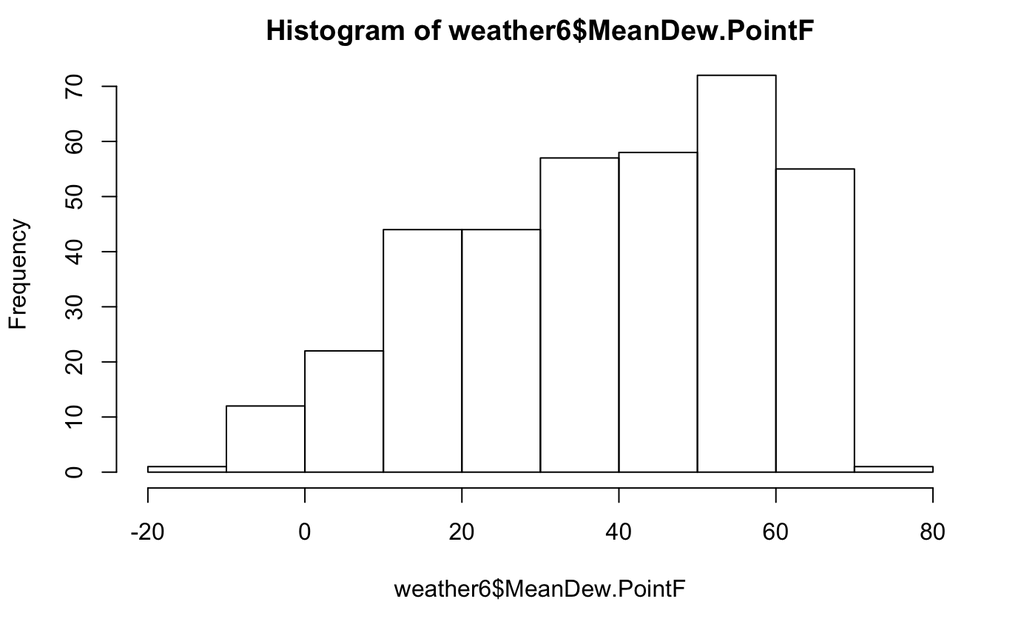

```r
# Look at histogram for MeanDew.PointF
hist(weather6$MeanDew.PointF)
```

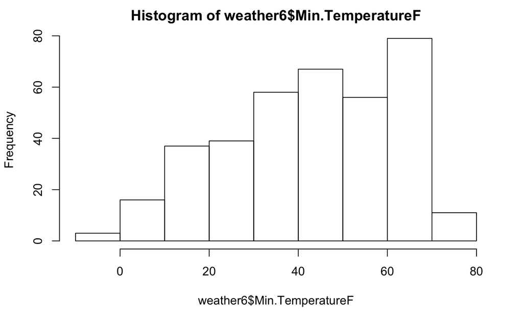

```r
# Look at histogram for Min.TemperatureF
hist(weather6$Min.TemperatureF)
```

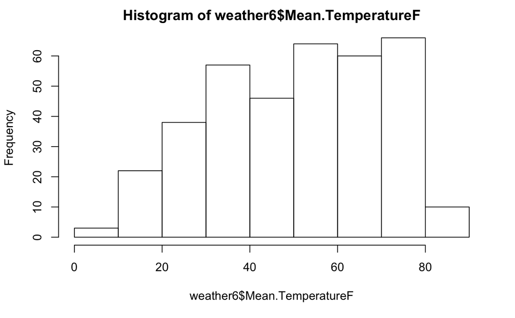

```r
# Compare to histogram for Mean.TemperatureF
hist(weather6$Mean.TemperatureF)
```

Finishing touches Before officially calling our weather data clean, we want to put a couple of finishing touches on the data. These are a bit more subjective and may not be necessary for analysis, but they will make the data easier for others to interpret, which is generally a good thing.

There are a number of stylistic conventions in the R language. Depending on who you ask, these conventions may vary. Because the period (.) has special meaning in certain situations, we generally recommend using underscores (_) to separate words in variable names. We also prefer all lowercase letters so that no one has to remember which letters are uppercase or lowercase.

Finally, the events column (renamed to be all lowercase in the first instruction) contains an empty string (“”) for any day on which there was no significant weather event such as rain, fog, a thunderstorm, etc. However, if it’s the first time you’re seeing these data, it may not be obvious that this is the case, so it’s best for us to be explicit and replace the empty strings with something more meaningful.

```r
new_colnames <- c("date", "events", "cloud_cover", "max_dew_point_f", "max_gust_speed_mph",         "max_humidity", "max_sea_level_pressure_in", "max_temperature_f", "max_visibility_miles", "max_wind_speed_mph", "mean_humidity", "mean_sea_level_pressure_in", "mean_temperature_f",          "mean_visibility_miles", "mean_wind_speed_mph", "mean_dew_point_f", "min_dew_point_f",            "min_humidity", "min_sea_level_pressure_in",  "min_temperature_f" , "min_visibility_miles",       "precipitation_in", "wind_dir_degrees" )
new_colnames
```

```
 [1] "date"                       "events"                     "cloud_cover"
 [4] "max_dew_point_f"            "max_gust_speed_mph"         "max_humidity"
 [7] "max_sea_level_pressure_in"  "max_temperature_f"          "max_visibility_miles"
[10] "max_wind_speed_mph"         "mean_humidity"              "mean_sea_level_pressure_in"
[13] "mean_temperature_f"         "mean_visibility_miles"      "mean_wind_speed_mph"
[16] "mean_dew_point_f"           "min_dew_point_f"            "min_humidity"
[19] "min_sea_level_pressure_in"  "min_temperature_f"          "min_visibility_miles"
[22] "precipitation_in"           "wind_dir_degrees"
```

```r
# Clean up column names
names(weather6) <- new_colnames
# Replace empty cells in events column
weather6$events[weather6$events == ""] <- "None"

# Print the first 6 rows of weather6
head(weather6)
```

|  | date | events | cloud_cover | max_dew_point_f | max_gust_speed_mph | max_humidity | max_sea_level_pressure_in | max_temperature_f | max_visibility_miles | max_wind_speed_mph | mean_humidity | mean_sea_level_pressure_in | mean_temperature_f | mean_visibility_miles | mean_wind_speed_mph | mean_dew_point_f | min_dew_point_f | min_humidity | min_sea_level_pressure_in | min_temperature_f | min_visibility_miles | precipitation_in | wind_dir_degrees |
| --- | --- | --- | --- | --- | --- | --- | --- | --- | --- | --- | --- | --- | --- | --- | --- | --- | --- | --- | --- | --- | --- | --- | --- |
| 1 | 2014-12-01 | Rain | 6 | 46 | 29 | 74 | 30.45 | 64 | 10 | 22 | 63 | 30.13 | 52 | 10 | 13 | 40 | 26 | 52 | 30.01 | 39 | 10 | 0.01 | 268 |
| 2 | 2014-12-10 | Rain | 8 | 45 | 29 | 100 | 29.58 | 48 | 10 | 23 | 95 | 29.50 | 43 | 3 | 13 | 39 | 37 | 89 | 29.43 | 38 | 1 | 0.28 | 357 |
| 3 | 2014-12-11 | Rain-Snow | 8 | 37 | 28 | 92 | 29.81 | 39 | 10 | 21 | 87 | 29.61 | 36 | 7 | 13 | 31 | 27 | 82 | 29.44 | 32 | 1 | 0.02 | 230 |
| 4 | 2014-12-12 | Snow | 7 | 28 | 21 | 85 | 29.88 | 39 | 10 | 16 | 75 | 29.85 | 35 | 10 | 11 | 27 | 25 | 64 | 29.81 | 31 | 7 | 0.00 | 286 |
| 5 | 2014-12-13 | None | 5 | 28 | 23 | 75 | 29.86 | 42 | 10 | 17 | 65 | 29.82 | 37 | 10 | 12 | 26 | 24 | 55 | 29.78 | 32 | 10 | 0.00 | 298 |
| 6 | 2014-12-14 | None | 4 | 29 | 20 | 82 | 29.91 | 45 | 10 | 15 | 68 | 29.83 | 39 | 10 | 10 | 27 | 25 | 53 | 29.78 | 33 | 10 | 0.00 | 306 |